# Relationship between muscle mass and strength

# The relationship between average cross-sectional area and 3 RM squat

## Introduction

Haun et al. (2019) conducted their study on 30 trained men who performed a 6 weeks resistance training intervention. Two groups were formed based on training outcome measures, where the top and bottom third of the data set were assigned to a high- (*n* = 10) and low-responder group (*n* = 10), respectively. The goal of the study was to examine if high responders would experience greater increases in myonuclear accretion as well as biomarkers related to ribosome biogenesis, androgen signaling, mTORc1 signaling, and mitochondrial biogenesis relative to low responders.

Maughan et al. (1983) have found a positive correlation between muscle strength and cross-sectional area in the knee-extensor muscles in both males and females. The goal of this report is to estimate the relationship between muscle mass and strength, measured as average cross-sectional area and 3 RM squat, respectively, both at T1. The whole data set was used, meaning we used data from all of the participants.

#### Null hypothesis

> At T1, there is no correlation between muscle mass measured as average cross-sectional area and muscle strength measured as 3 RM squat, both when and when not controlling for body mass

#### Alternative hypothesis

> At T1, there is a positive correlation between muscle mass measured as average cross-sectional area and muscle strength measured as 3 RM squat, both when and when not controlling for body mass

## Methods

Pearson’s product-moment correlation was used to estimate the correlation between average cross-sectional area and 3 RM squat at T1. r < 0.1 = trivial, 0.1-0.3 = small, 0.3-0.5 = moderate, 0.5-0.7 = large, 0.7-0.9 = very large, 0.9 = almost perfect and 1.0 = perfect correlation (Hopkins 2009). A regression model was also used to fit the data, with the average cross-sectional area as the predictor, and 3 RM squat as the dependent variable. The regression model also controlled for body mass. Tests to check for constant variance, normal residuals and problematic observations were performed. No problematic observations were found, so we could safely use all the observations in the analysis

## Results

#### Correlation model

There was a 0.02 correlation between average cross-sectional area and 3 RM squat at T1 (95% CI: [-0.342, 0.378], *t*(28) = 0.109, *p* = 0.91).

#### Regression model

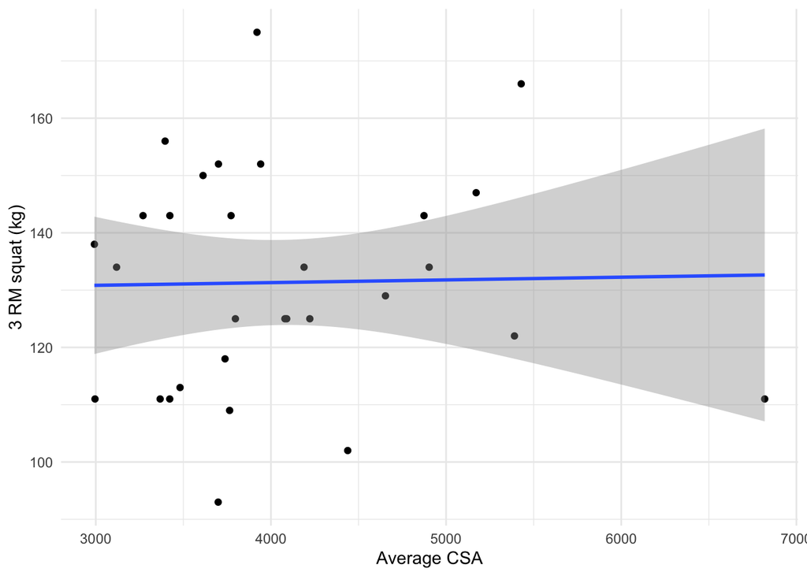

Figure1: The relationship between muscle mass and strength. Using a regression model with the average cross-sectional area as the predictor, and 3 RM squat as the dependent variable

Table1: The relationship between muscle mass and strength. Using a regression model with the average cross-sectional area as the predictor, and 3 RM squat as the dependent variable

|  | Estimate | SE | t-statistic | p-value |
| --- | --- | --- | --- | --- |
| (Intercept) | 25.6553 | 26.5183 | 0.9675 | 0.3419 |
| AVG_CSA_T1 | 0.0028 | 0.0033 | 0.8411 | 0.4077 |
| T1_BODY_MASS | 1.1373 | 0.2490 | 4.5677 | 0.0001 |

When using the regression model and controlling for body mass, there was no relationship between average cross-sectional area and 3 RM squat at T1 (95% CI: [-0.004, 0.01], *t*(27) = 0.841, *p* = 0.408).

## Discussion

#### Correlation model

The correlation estimate (0.02) is less than 0.1, which indicates a *trivial* correlation between average cross-sectional area and 3 RM squat at T1 (Hopkins 2009).

As the confidence interval contain 0 (95% CI: [-0.342, 0.378]), we can not reject the null hypothesis that states that “at T1, there is no correlation between muscle mass measured as average cross-sectional area and muscle strength measured as 3 RM squat, both when and when not controlling for body mass.” This is supported by the *p*-value (0.91).

#### Regression model

We can se from the regression table that for every unit increase in average cross-sectional area, 3 RM squat increases with 0,0028 kg.

#### Conclusion

The findings from Haun et al. (2019) therefore suggests that there is no relationship between average cross-sectional area and 3 RM squat in trained men before starting a training intervention, both when and when not controlling for body mass.

## References

Haun, C. T., C. G. Vann, C. B. Mobley, S. C. Osburn, P. W. Mumford, P. A. Roberson, M. A. Romero, et al. 2019. “Pre-training Skeletal Muscle Fiber Size and Predominant Fiber Type Best Predict Hypertrophic Responses to 6 Weeks of Resistance Training in Previously Trained Young Men.” *Front Physiol* 10: 297.

Hopkins, et al., W. G. 2009. “Progressive Statistics for Studies in Sports Medicine and Exercise Science.” *Med Sci Sports Exerc* 41: 3–13.

Maughan, R J, J S Watson, and J Weir. 1983. “Strength and Cross-Sectional Area of Human Skeletal Muscle.” *The Journal of Physiology* 338 (1): 37–49.